# Lesson 5

### Multivariate Data

Notes: We are going to examine three or more quantative variables

### Moira Perceived Audience Size Colored by Age

Notes: we are going to look at the same scatterplot of perceived audience size and actual audience size,but with age as a colored layer. The plot is still overplotted and color does not add much help

### Third Qualitative Variable

Notes:

```r
pf <- read.csv('pseudo_facebook.tsv', sep= "\t")
library(dplyr)
pf.fc_by_age_gender <- pf %>%
  filter(!is.na(pf$gender))  %>%
  group_by(age, gender)  %>%
  summarise(mean_friend_count= mean(friend_count),
            median_friend_count= median(friend_count),
            n = n())  %>%
  ungroup()  %>%
  arrange(age)

head(pf.fc_by_age_gender)
```

```
## # A tibble: 6 x 5
##     age gender mean_friend_count median_friend_count     n
##   <int> <fct>              <dbl>               <dbl> <int>
## 1    13 female              259.               148     193
## 2    13 male                102.                55     291
## 3    14 female              362.               224     847
## 4    14 male                164.                92.5  1078
## 5    15 female              539.               276    1139
## 6    15 male                201.               106.   1478
```

### Plotting Conditional Summaries

Notes: we do not need to include stat and fun.y parameters since we already used dplyr package to summarize the data. do not use the following code below: ggplot(aes(x = age, y = friend_count), data = subset(pf, !is.na(gender))) + geom_line(aes(color = gender), stat = ‘summary’, fun.y = median)

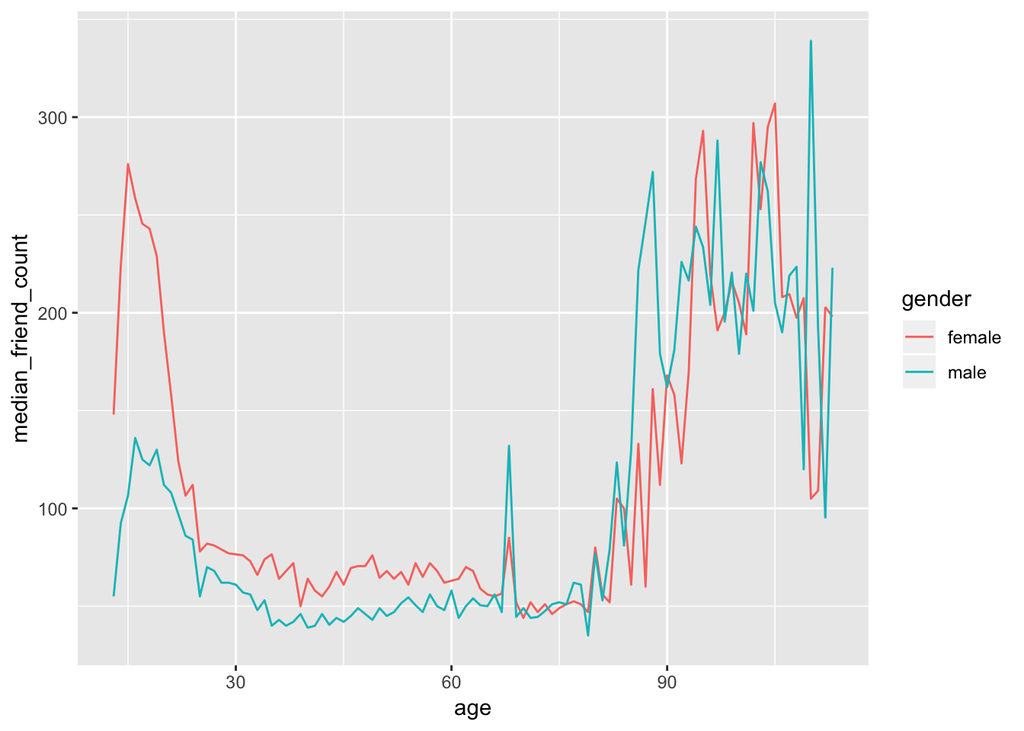

```r
library(ggplot2)
ggplot(aes(x=age, y=median_friend_count), data= pf.fc_by_age_gender) + geom_line(aes(color=gender))
```

### Thinking in Ratios

Notes: Lets think in ratios. How many more friends does the female gender have more than males?

### Wide and Long Format

Notes: We are going to reshape the dataframe from long format to wide format. We can use tidyr package or reshape2 package.

### Reshaping Data

Notes: dcast function will allow you to make a new dataframe from long to wide format. melt function will reverse this and convert wide format to long format. We can use dplyr and tidyr packages to create the same dataframe with the code: pf.fc_by_age_gender.wide <- subset(pf.fc_by_age_gender[c(‘age’, ‘gender’, ‘median_friend_count’)], !is.na(gender)) %>% spread(gender, median_friend_count) %>% mutate(ratio = male / female)

head(pf.fc_by_age_gender.wide)

```r
library(reshape2)

pf.fc_by_age_gender.wide <- dcast(pf.fc_by_age_gender,
                                  age ~ gender,
                                  value.var = 'median_friend_count')

head(pf.fc_by_age_gender.wide)
```

```
##   age female  male
## 1  13  148.0  55.0
## 2  14  224.0  92.5
## 3  15  276.0 106.5
## 4  16  258.5 136.0
## 5  17  245.5 125.0
## 6  18  243.0 122.0
```

### Ratio Plot

Notes: we need to use geom_hline as a baseline to see if females or males have more average friend counts.

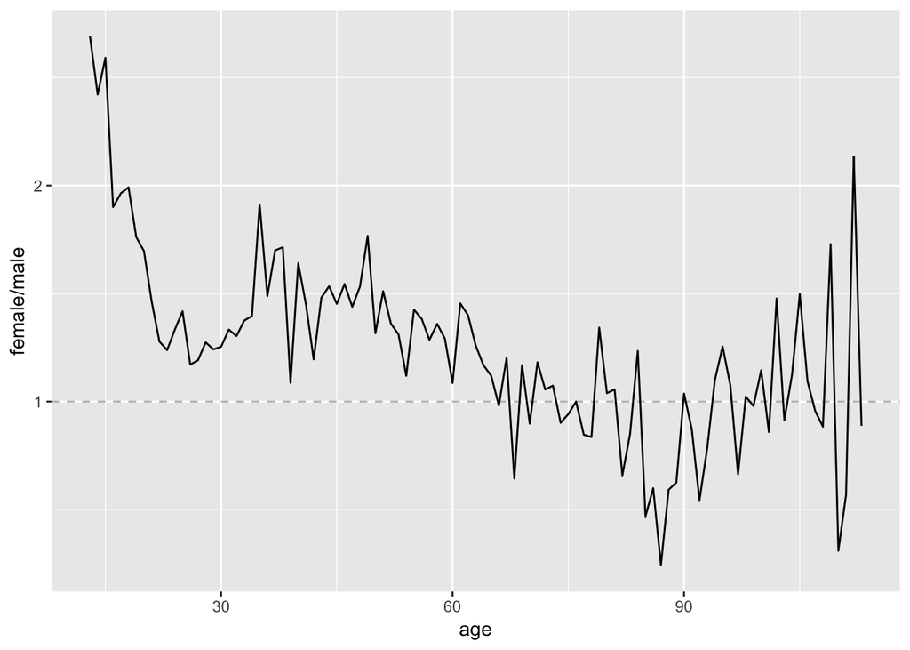

```r
ggplot(aes(x=age, y = female/male), data= pf.fc_by_age_gender.wide) +
  geom_line() +
  geom_hline(yintercept= 1, alpha=0.3, linetype= 2)
```

### Third Quantitative Variable

Notes:tenure is somewhat like age in that it describes how long a person has been a member of facebook.Create a variable called year_joined in the pf data frame using the variable tenure and 2014 as the reference year.

```r
pf$year_joined <- floor(2014 - (pf$tenure / 365))
```

### Cut a Variable

Notes: Create a new variable in the data frame called year_joined.bucket by using the cut function on the variable year_joined. You can look up the cut function for help.

```r
pf$year_joined.bucket <- cut(pf$year_joined, breaks= c(2004, 2009, 2011, 2012, 2014))
```

### Plotting it All Together

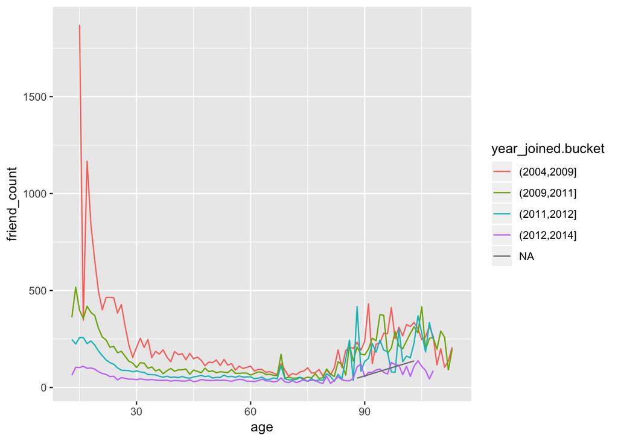

```r
ggplot(aes(x = age, y = friend_count),
       data = subset(pf, !is.na(gender))) +
  geom_line(aes(color = year_joined.bucket), stat = 'summary', fun.y = median)
```

### Plot the Grand Mean

Notes: Write code to do the following: (1) Add another geom_line to code below to plot the grand mean of the friend count vs age. (2) Exclude any users whose year_joined.bucket is NA. (3) Use a different line type for the grand mean. As a reminder, the parameter linetype can take the values 0-6: 0 = blank, 1 = solid, 2 = dashed, 3 = dotted, 4 = dotdash, 5 = longdash, 6 = twodash

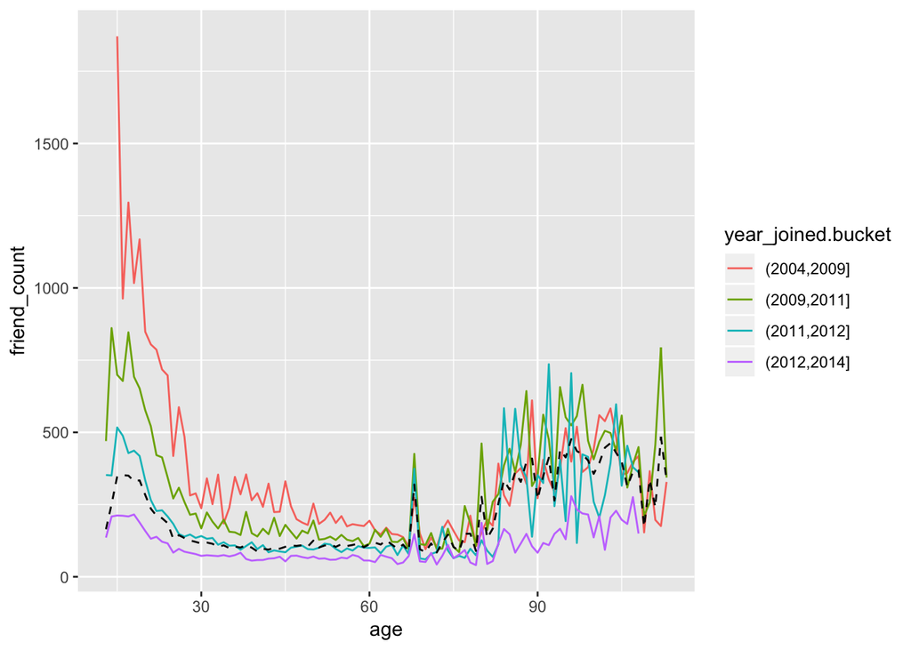

```r
ggplot(aes(x = age, y = friend_count),
       data = subset(pf, !is.na(year_joined.bucket))) +
  geom_line(aes(color = year_joined.bucket), stat = 'summary', fun.y = mean) +
  geom_line(stat= 'summary', fun.y= mean, linetype= 2)
```

### Friending Rate

Notes: What is the median and maximum friend rate with users of at least 1 day of tenure? Subset data so that we only get friend_count per tenure and provide a summary of statistics.

```r
with(subset(pf, tenure >=1), summary(friend_count/tenure))
```

```
##     Min.  1st Qu.   Median     Mean  3rd Qu.     Max.
##   0.0000   0.0775   0.2205   0.6096   0.5658 417.0000
```

### Friendships Initiated

What is the median friend rate? 0.2205

What is the maximum friend rate? 417

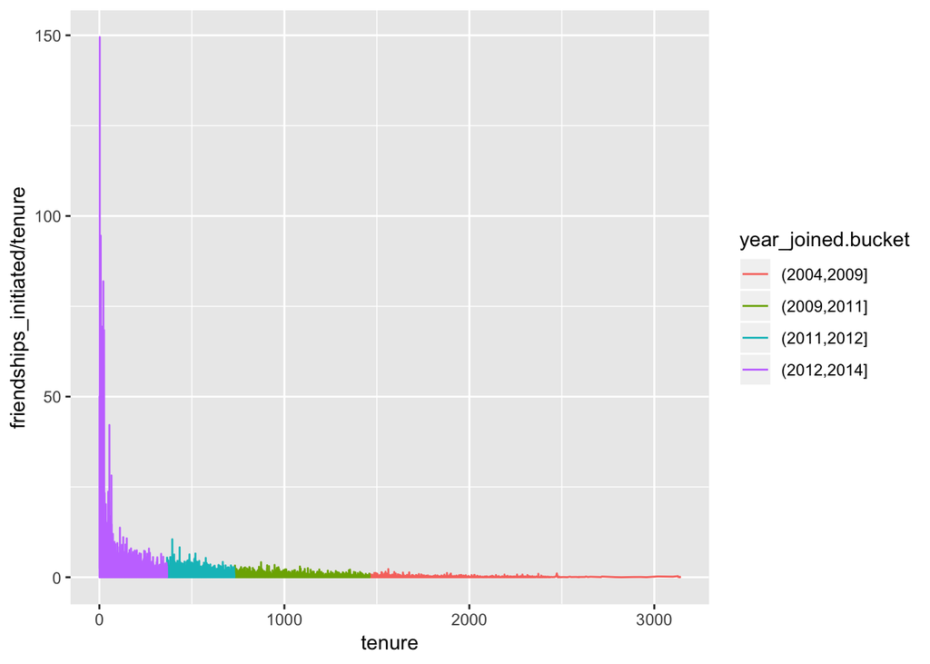

```r
ggplot(aes(x=tenure, y=friendships_initiated / tenure),
       data = subset(pf, tenure >= 1)) +
  geom_line(aes(color = year_joined.bucket))
```

### Bias-Variance Tradeoff Revisited

Notes: Instead of geom_line(), use geom_smooth() to add a smoother to the plot. You can use the defaults for geom_smooth() but do color the line by year_joined.bucket

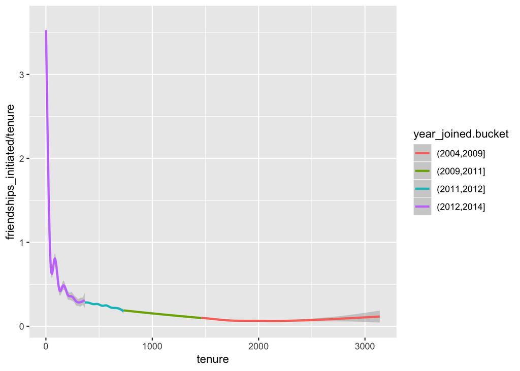

```r
ggplot(aes(x = tenure, y = friendships_initiated / tenure),
       data = subset(pf, tenure >= 1)) +
  geom_smooth(aes(color = year_joined.bucket))
```

### Sean’s NFL Fan Sentiment Study

Notes: As you smooth out the graph, you lose variance but gain bias.

### Introducing the Yogurt Data Set

Notes:

### Histograms Revisited

Notes:

```r
getwd()
```

```
## [1] "/Users/JoJo/Documents/Data Analysis:Science/Udacity/DAND/Part 6/eda-course-materials/lesson5"
```

```r
yo <- read.csv('yogurt.csv')
str(yo)
```

```
## 'data.frame':    2380 obs. of  9 variables:
##  $ obs        : int  1 2 3 4 5 6 7 8 9 10 ...
##  $ id         : int  2100081 2100081 2100081 2100081 2100081 2100081 2100081 2100081 2100081 2100081 ...
##  $ time       : int  9678 9697 9825 9999 10015 10029 10036 10042 10083 10091 ...
##  $ strawberry : int  0 0 0 0 1 1 0 0 0 0 ...
##  $ blueberry  : int  0 0 0 0 0 0 0 0 0 0 ...
##  $ pina.colada: int  0 0 0 0 1 2 0 0 0 0 ...
##  $ plain      : int  0 0 0 0 0 0 0 0 0 0 ...
##  $ mixed.berry: int  1 1 1 1 1 1 1 1 1 1 ...
##  $ price      : num  59 59 65 65 49 ...
```

```r
# Change the ID from an integer to a factor
yo$id <- factor(yo$id)
str(yo)
```

```
## 'data.frame':    2380 obs. of  9 variables:
##  $ obs        : int  1 2 3 4 5 6 7 8 9 10 ...
##  $ id         : Factor w/ 332 levels "2100081","2100370",..: 1 1 1 1 1 1 1 1 1 1 ...
##  $ time       : int  9678 9697 9825 9999 10015 10029 10036 10042 10083 10091 ...
##  $ strawberry : int  0 0 0 0 1 1 0 0 0 0 ...
##  $ blueberry  : int  0 0 0 0 0 0 0 0 0 0 ...
##  $ pina.colada: int  0 0 0 0 1 2 0 0 0 0 ...
##  $ plain      : int  0 0 0 0 0 0 0 0 0 0 ...
##  $ mixed.berry: int  1 1 1 1 1 1 1 1 1 1 ...
##  $ price      : num  59 59 65 65 49 ...
```

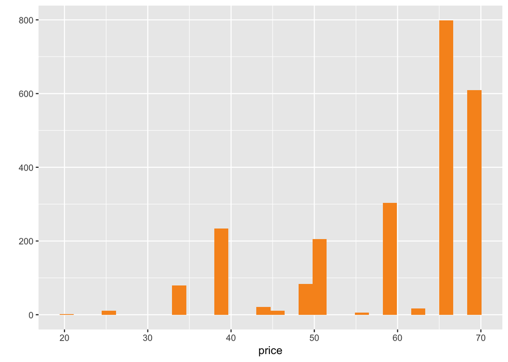

```r
# Create a histogram of yogurt prices
qplot(data= yo, x= price, fill = I('#F79420'))
```

### Number of Purchases

Notes: Create a new variable called all.purchases, which gives the total counts of yogurt for each observation or household.

One way to do this is using the transform function. You can look up the function transform and run the examples of code at the bottom of the documentation to figure out what it does.

The transform function produces a data frame so if you use it then save the result to ‘yo’!

```r
?transform
yo <- transform(yo, all.purchases = (strawberry + blueberry + pina.colada + plain + mixed.berry))
```

### Prices over Time

Notes: Create a scatterplot of price vs time.

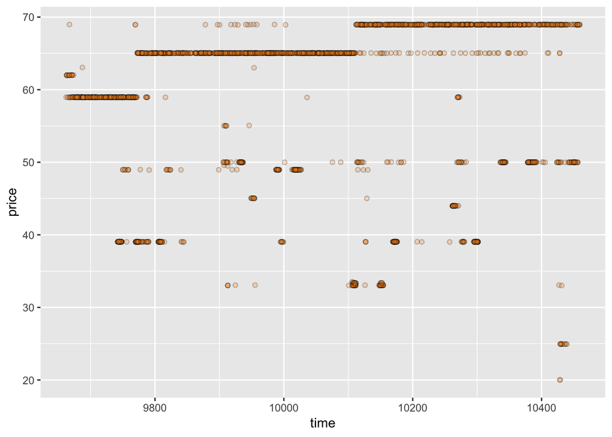

```r
ggplot(aes(x= time, y= price), data = yo) + geom_jitter(alpha = 1/4, shape = 21, fill = I('#F79420'))
```

### Sampling Observations

Notes:

### Looking at Samples of Households

### The Limits of Cross Sectional Data

Notes:

### Many Variables

Notes:

### Scatterplot Matrix

Notes:

```r
#install.packages(GGally)
library(GGally)
theme_set(theme_minimal(20))

# set the seed for reproducible results
set.seed(1836)
pf_subset <- pf[, c(2:15)]
names(pf_subset)
```

```
##  [1] "age"                   "dob_day"
##  [3] "dob_year"              "dob_month"
##  [5] "gender"                "tenure"
##  [7] "friend_count"          "friendships_initiated"
##  [9] "likes"                 "likes_received"
## [11] "mobile_likes"          "mobile_likes_received"
## [13] "www_likes"             "www_likes_received"
```

[figure not shown]

```r
ggpairs(pf_subset[sample.int(nrow(pf_subset), 1000), ])
```

***

### Even More Variables

Notes:

```r
nci <- read.table("nci.tsv")
colnames(nci) <- c(1:64)
```

### Heat Maps

Notes:

```r
# melt data to long format
library(reshape2)
nci.long.samp <- melt(as.matrix(nci[1:200,]))
names(nci.long.samp) <- c("gene", "case", "value")
head(nci.long.samp)
```

```
##   gene case  value
## 1    1    1  0.300
## 2    2    1  1.180
## 3    3    1  0.550
## 4    4    1  1.140
## 5    5    1 -0.265
## 6    6    1 -0.070
```

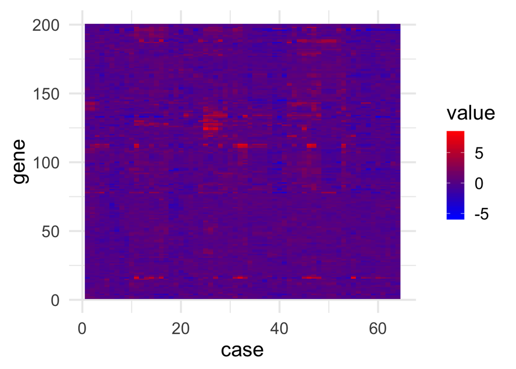

```r
# make the heat map
ggplot(aes(y = gene, x = case, fill = value),
  data = nci.long.samp) +
  geom_tile() +
  scale_fill_gradientn(colours = colorRampPalette(c("blue", "red"))(100))
```

### Analyzing Three of More Variables

Reflection: wide and long data, reshaping data, different plotting methods, geom_smooth, different methods of plotting with cross-sectional data vs. longitudinal data, scatterplot matrices, and heat maps

Click **KnitHTML** to see all of your hard work and to have an html page of this lesson, your answers, and your notes!